# Analysis of Obesity in the US

Collin, Erzhan, Jaime, Kailynn

11/20/2022

Code name: Yum Yum

Affiliation: Info 201

## Abstract:

In this project, we are concerned with the issue of obesity, specifically, the prevalence of the rates in the US. This topic is important because according to the data collected from the National Institutes of Health (NIH), more than 2 in 5 adults (42.4%) have obesity and almost 1 in 5 children and adolescents ages 2 to 19 (19.3%) have obesity. To address this concern we plan to analyze datasets to examine the many factors that contribute to this issue.

## Keywords:

obesity, geography, race, exercise

## Summary Information:

Obesity rates in the United States was the topic of interest for our project. The data utilized in this project helped to present valuable information and see the prevalence of obesity by geographic location, sex, and race. One of the datasets we used in our project was a physical activity dataset that recorded the percentage of sufficient physical activity prevalence of male and females for each state and county. From this, a total of 3194 observations were made from the states, counties, and country as a whole. Furthermore, the data indicates that the state with the highest prevalence of female physical activity in 2011 was Vermont, while the state with the highest prevalence of male physical activity in 2011 was Hawaii. In addition, the highest change in one state for female physical activity prevalence from 2001 to 2009 was 10.4 while the highest change in one state for male physical activity prevalence from 2001 to 2009 was 6.8.

## Introduction:

“It is health that is the real wealth, and not pieces of gold and silver.” – Mahatma Gandhi. As obesity remains one of the main health and social issues in the US, why is it so important and why should we be concerned ? According to the CDC, annual obesity-related medical care costs in the United States, in 2019, were estimated to be nearly $173 billion dollars. Annual nationwide productivity costs of obesity-related absenteeism range between $3.38 billion ($79 per individual with obesity) and $6.38 billion ($132 per individual with obesity). Preventive, diagnostic, and therapeutic services may all be included in direct medical costs. Lost productivity is included in indirect expenses associated with illness and mortality. Employee absences from work due to obesity-related health issues, decreased productivity at work, and early death and disability are all examples of productivity measurements. Another reason is military readiness, over one third of young adults (17–24) are too obese to join the US military. Only 3 out of 4 young adults who satisfy the weight standards report having levels of physical activity that equip them for the difficulties of basic training. As a result, just 2 in 5 young adults are sufficiently active and within the weight requirements for military service. Additionally, from 16% in 2015 to 19% of active-duty service personnel in 2020 were obese. These people are less likely to be in good health and be able to deploy. More than 3.6 million musculoskeletal injuries occurred to active-duty soldiers between 2008 and 2017. According to one study, obese active-duty troops had a 33% higher risk of suffering this kind of injury.

## The Problem Domain:

# Project framing:

Referencing The New York Times, a study done by medical scientists, “…projected that by 2030, nearly one in two adults will be obese,” (Brody). The problem domain we are presenting concerns obesity in the U.S. and as it persists, the factors correlated to this issue. The main question that we strive to address is “What factors impact the obesity levels in the U.S.?” Upon this, we will consider questions including: how does geography affect obesity, how does race/ethnicity influence obesity, and how does school funding impact childhood obesity rates/how does economic status affect obesity?

# Human Values:

According to the National Institutes of Health (NIH), various studies have reported harmful stereotypes that those who are overweight or obese are, “lazy, weak-willed, unsuccessful, unintelligent, lack self-discipline, have poor willpower, and are noncompliant with weight-loss treatment,” (Puhl, Heuer). As a result of these stigmas, prejudice of obese individuals is commonly experienced in workplaces, health facilities, schools, and mass media. Once more referencing the NIH, “the prevalence of weight discrimination has increased by 66% over the past decade, and is now comparable to prevalence rates of racial discrimination in America.” While these opinions generally sprout from the notion that sustaining a healthy lifestyle is important, this should not deter from the fact that there are external factors that contribute to obesity which need to be addressed.

# Direct and Indirect Stakeholders:

The direct stakeholders of this topic are the obese population in the US. As this project centers around this group and they are the ones living with this chronic health condition, this topic affects them the most directly. They may be interested in gaining information about the external components that are related to obesity. The indirect stakeholders are the ones who are not experiencing this health condition firsthand, but are associating themselves with the conversation either by obligation or choice. This includes health care facilities, mass media, workplaces, and schools.

# Potential Harms and Benefits:

If interventions are taken with data and technology, a possible benefit could be bringing awareness and diminishing the harmful stigma that obesity is solely a choice. Rather than having this negative outlook, it should encourage the conversation of living a healthier lifestyle, one that includes a nutritious diet, exercise, and improvements on mental health. Furthermore, as stated by the BMC, “obese is a major risk factor for many chronic diseases including heart disease, cancer, kidney failure, pulmonary disease and diabetes,” thus needs to be addressed for preventative action (Pearce, et al.). However, acknowledging that data and technology simply presents data, this will not stop negative stereotypes. If the data shows that one ethnical or racial group has high percentages of obesity, this may create a stigma that this group as a whole is obese. This applies to the other variables as well such as socioeconomic status, region of residency, and age.

## Expected Implications:

We expect the data to imply that communities with lower incomes experience higher rates of obesity, due to the fact that eating unhealthy processed foods in America has become significantly cheaper than eating a balanced diet. We also suspect that historically marginalized groups of people (such as African Americans) will experience disproportionate rates of obesity because these groups usually have less access to healthy foods and health resources. The data will most likely imply that factors that affect an individual’s economic status, such as race and location, are what affect a person’s likelihood of obesity.

## Limitations:

There isn’t one set factor that contributes to obesity. There are some factors such as having a high metabolism that vary from person to person. Genetic attributes like these are hard to gather data for. Another limitation is that there is not enough data to represent everyone in the US. Even if there was, it would be extremely hard for us to process all the data. Everyone’s body makeup is unique and there are different factors that can all contribute to obesity. This makes having more data a better representation of the US population.

## Table:

| State | Male Obesity Rate 2001 | Female Obesity Rate 2001 | Male Obesity Rate 2009 | Female Obesity Rate 2009 | Male Obesity Rate 2011 | Female Obesity Rate 2011 | Male Obesity Rate Difference 2001-2009 | Female Obesity Rate Difference 2001-2009 | Male Sufficient PA Prevalence 2001 | Female Sufficient PA Prevalence 2001 | Male Sufficient PA Prevalence 2009 | Female Sufficient PA Prevalence 2009 | Male Sufficient PA Prevalence 2011 | Female Sufficient PA Prevalence 2011 | Male Sufficient PA Prevalence Difference 2001-2009 | Female Sufficient PA Prevalence Difference 2001-2009 |
| --- | --- | --- | --- | --- | --- | --- | --- | --- | --- | --- | --- | --- | --- | --- | --- | --- |
| United States | 26.1 | 28.7 | 32.8 | 35.1 | 33.8 | 36.1 | 6.7 | 6.4 | 56.8 | 46.7 | 57.8 | 51.3 | 56.3 | 52.6 | 1.0 | 4.7 |
| Alabama | 29.7 | 34.1 | 36.1 | 41.2 | 37.3 | 42.2 | 6.4 | 7.1 | 52.4 | 40.4 | 51.5 | 41.4 | 49.5 | 42.0 | -0.9 | 1.0 |
| Alaska | 26.7 | 31.8 | 32.8 | 36.7 | 33.8 | 37.6 | 6.1 | 4.9 | 63.9 | 53.5 | 61.9 | 56.7 | 59.8 | 57.6 | -2.0 | 3.3 |
| Arizona | 25.2 | 25.5 | 31.6 | 32.8 | 32.4 | 33.8 | 6.4 | 7.3 | 61.3 | 51.8 | 60.9 | 55.2 | 59.5 | 56.9 | -0.3 | 3.4 |
| Arkansas | 28.8 | 32.0 | 36.1 | 38.4 | 37.2 | 39.3 | 7.3 | 6.4 | 52.4 | 41.4 | 53.6 | 44.3 | 51.3 | 45.2 | 1.2 | 2.9 |
| California | 24.1 | 27.4 | 28.7 | 32.0 | 29.4 | 32.9 | 4.6 | 4.6 | 59.4 | 50.7 | 61.4 | 57.0 | 61.3 | 59.2 | 2.0 | 6.2 |
| Colorado | 20.3 | 21.4 | 25.8 | 26.9 | 26.8 | 27.7 | 5.5 | 5.5 | 64.8 | 56.8 | 65.7 | 61.4 | 64.7 | 62.7 | 0.9 | 4.6 |
| Connecticut | 23.7 | 24.2 | 29.7 | 31.4 | 30.7 | 32.4 | 6.0 | 7.2 | 58.8 | 50.0 | 59.4 | 53.8 | 57.5 | 54.4 | 0.7 | 3.7 |
| Delaware | 27.0 | 29.1 | 35.9 | 37.1 | 36.9 | 37.8 | 8.9 | 8.1 | 54.8 | 42.6 | 57.2 | 49.1 | 54.0 | 49.2 | 2.4 | 6.5 |
| District of Columbia | 17.9 | 28.3 | 21.6 | 34.3 | 22.4 | 35.3 | 3.7 | 6.0 | 63.9 | 50.2 | 63.5 | 56.8 | 62.6 | 57.9 | -0.3 | 6.6 |
| Florida | 25.6 | 27.3 | 33.2 | 33.0 | 34.3 | 34.0 | 7.7 | 5.7 | 55.6 | 45.8 | 56.7 | 51.4 | 56.0 | 52.8 | 1.1 | 5.6 |
| Georgia | 27.4 | 31.7 | 33.6 | 37.1 | 34.6 | 38.1 | 6.2 | 5.4 | 53.9 | 41.5 | 56.4 | 49.7 | 54.6 | 50.8 | 2.5 | 8.2 |
| Hawaii | 21.5 | 19.4 | 27.4 | 25.4 | 28.4 | 26.1 | 5.9 | 6.0 | 68.9 | 55.2 | 68.9 | 59.8 | 66.0 | 60.9 | 0.1 | 4.5 |
| Idaho | 26.4 | 27.1 | 32.8 | 34.0 | 33.9 | 35.0 | 6.4 | 6.9 | 62.5 | 54.9 | 62.1 | 57.5 | 60.5 | 58.7 | -0.4 | 2.6 |
| Illinois | 25.7 | 29.0 | 32.9 | 35.3 | 33.9 | 36.3 | 7.2 | 6.3 | 54.0 | 43.4 | 56.7 | 52.7 | 54.8 | 54.2 | 2.7 | 9.3 |
| Indiana | 28.2 | 30.6 | 35.1 | 38.5 | 36.3 | 39.5 | 6.9 | 8.0 | 56.1 | 45.2 | 54.6 | 46.6 | 52.5 | 47.6 | -1.5 | 1.5 |
| Iowa | 27.3 | 28.6 | 35.2 | 34.9 | 36.3 | 35.9 | 7.9 | 6.3 | 56.0 | 46.6 | 56.4 | 51.7 | 54.1 | 52.9 | 0.4 | 5.2 |
| Kansas | 26.6 | 28.2 | 34.7 | 36.4 | 35.8 | 37.3 | 8.1 | 8.2 | 54.8 | 46.2 | 56.6 | 50.1 | 53.5 | 50.5 | 1.8 | 3.9 |
| Kentucky | 28.9 | 31.1 | 36.3 | 38.4 | 37.5 | 39.3 | 7.4 | 7.3 | 44.5 | 33.6 | 51.3 | 44.0 | 49.9 | 45.8 | 6.8 | 10.4 |
| Louisiana | 29.5 | 33.8 | 38.2 | 40.5 | 39.4 | 41.7 | 8.7 | 6.7 | 47.7 | 36.4 | 51.9 | 42.0 | 49.8 | 42.8 | 4.3 | 5.6 |
| Maine | 24.4 | 26.5 | 31.7 | 33.8 | 32.8 | 34.9 | 7.2 | 7.4 | 60.4 | 53.3 | 62.4 | 58.1 | 60.7 | 59.0 | 2.1 | 4.8 |
| Maryland | 25.4 | 28.6 | 32.8 | 36.1 | 33.9 | 36.9 | 7.4 | 7.5 | 59.1 | 47.6 | 57.2 | 51.2 | 55.4 | 51.7 | -1.9 | 3.6 |
| Massachusetts | 22.9 | 23.8 | 30.0 | 30.3 | 31.0 | 31.1 | 7.1 | 6.5 | 60.9 | 50.9 | 59.9 | 54.3 | 59.6 | 55.7 | -1.0 | 3.4 |
| Michigan | 28.0 | 31.6 | 35.6 | 38.4 | 36.6 | 39.5 | 7.6 | 6.9 | 57.7 | 48.6 | 59.2 | 52.8 | 57.8 | 53.8 | 1.5 | 4.1 |
| Minnesota | 26.1 | 27.1 | 32.4 | 32.5 | 33.4 | 33.3 | 6.2 | 5.4 | 61.5 | 53.9 | 61.1 | 55.6 | 59.8 | 56.8 | -0.4 | 1.7 |
| Mississippi | 30.3 | 36.4 | 37.9 | 43.5 | 39.1 | 44.5 | 7.5 | 7.0 | 48.4 | 35.7 | 49.6 | 38.8 | 47.2 | 39.7 | 1.2 | 3.1 |
| Missouri | 28.1 | 30.0 | 35.6 | 38.0 | 36.6 | 38.9 | 7.4 | 8.0 | 55.7 | 45.6 | 55.5 | 49.3 | 53.6 | 50.3 | -0.1 | 3.7 |
| Montana | 24.0 | 24.8 | 30.2 | 31.2 | 31.3 | 32.0 | 6.2 | 6.4 | 62.1 | 54.9 | 62.4 | 57.9 | 60.4 | 58.5 | 0.4 | 3.0 |
| Nebraska | 27.3 | 28.0 | 34.9 | 35.6 | 36.1 | 36.5 | 7.7 | 7.6 | 55.1 | 45.0 | 57.0 | 52.1 | 53.7 | 52.7 | 1.9 | 7.1 |
| Nevada | 26.4 | 25.7 | 32.3 | 31.1 | 33.0 | 32.1 | 6.0 | 5.3 | 60.0 | 49.8 | 57.6 | 50.6 | 56.3 | 51.6 | -2.4 | 0.8 |
| New Hampshire | 24.3 | 24.6 | 32.3 | 32.0 | 33.5 | 32.7 | 8.1 | 7.4 | 64.4 | 54.9 | 62.8 | 57.5 | 61.0 | 57.9 | -1.6 | 2.7 |
| New Jersey | 24.9 | 26.3 | 31.6 | 31.5 | 32.6 | 32.2 | 6.6 | 5.2 | 54.9 | 44.2 | 57.1 | 50.0 | 56.2 | 51.9 | 2.3 | 5.8 |
| New Mexico | 23.1 | 27.9 | 30.1 | 34.0 | 31.2 | 34.9 | 7.1 | 6.1 | 60.2 | 50.5 | 60.4 | 53.6 | 57.8 | 54.5 | 0.2 | 3.1 |
| New York | 23.9 | 26.9 | 30.2 | 32.9 | 31.2 | 33.8 | 6.3 | 5.9 | 53.3 | 44.3 | 56.3 | 49.4 | 55.3 | 50.8 | 3.0 | 5.1 |
| North Carolina | 27.1 | 31.4 | 33.8 | 37.7 | 34.9 | 38.6 | 6.7 | 6.3 | 54.4 | 42.0 | 56.1 | 47.3 | 54.3 | 48.2 | 1.7 | 5.3 |
| North Dakota | 29.1 | 28.2 | 35.3 | 34.8 | 36.5 | 35.6 | 6.2 | 6.6 | 56.1 | 49.4 | 56.8 | 52.4 | 53.7 | 52.8 | 0.7 | 3.0 |
| Ohio | 27.5 | 29.7 | 35.6 | 37.6 | 36.7 | 38.5 | 8.0 | 8.0 | 56.8 | 45.6 | 57.1 | 49.6 | 55.4 | 50.9 | 0.4 | 4.1 |
| Oklahoma | 27.9 | 29.8 | 36.1 | 38.4 | 37.2 | 39.4 | 8.2 | 8.6 | 50.7 | 41.1 | 53.0 | 46.0 | 50.6 | 46.7 | 2.3 | 4.8 |
| Oregon | 24.6 | 27.6 | 31.9 | 33.4 | 32.9 | 34.5 | 7.2 | 5.9 | 65.2 | 56.6 | 64.0 | 60.9 | 63.2 | 62.4 | -1.2 | 4.2 |
| Pennsylvania | 27.0 | 29.7 | 34.2 | 36.7 | 35.3 | 37.6 | 7.2 | 7.0 | 57.1 | 48.0 | 57.8 | 50.4 | 55.8 | 51.2 | 0.7 | 2.4 |
| Rhode Island | 23.5 | 25.4 | 31.8 | 32.4 | 32.9 | 33.6 | 8.2 | 7.0 | 58.2 | 48.2 | 56.4 | 50.2 | 54.7 | 50.5 | -1.8 | 1.9 |
| South Carolina | 28.4 | 31.6 | 34.2 | 39.6 | 35.4 | 40.7 | 5.8 | 8.0 | 58.0 | 43.3 | 57.1 | 48.0 | 55.1 | 49.1 | -0.9 | 4.7 |
| South Dakota | 28.1 | 28.3 | 34.9 | 34.8 | 36.0 | 35.6 | 6.8 | 6.5 | 54.2 | 49.0 | 54.9 | 51.1 | 52.3 | 52.0 | 0.8 | 2.1 |
| Tennessee | 28.9 | 31.4 | 35.0 | 38.9 | 36.1 | 39.9 | 6.1 | 7.5 | 48.8 | 36.3 | 48.8 | 39.2 | 46.7 | 39.9 | 0.0 | 3.0 |
| Texas | 27.7 | 31.3 | 34.9 | 38.0 | 36.0 | 38.9 | 7.2 | 6.7 | 55.2 | 44.1 | 56.4 | 48.4 | 54.1 | 49.5 | 1.3 | 4.3 |
| Utah | 24.9 | 25.7 | 31.7 | 31.6 | 32.6 | 32.6 | 6.8 | 5.9 | 64.1 | 56.4 | 63.5 | 57.4 | 60.2 | 57.6 | -0.6 | 0.9 |
| Vermont | 21.8 | 24.0 | 28.4 | 29.8 | 29.6 | 30.6 | 6.7 | 5.8 | 65.3 | 58.2 | 65.1 | 61.8 | 63.7 | 62.8 | -0.2 | 3.6 |
| Virginia | 26.3 | 28.9 | 32.7 | 35.4 | 33.7 | 36.2 | 6.4 | 6.5 | 59.7 | 47.0 | 58.0 | 52.6 | 56.4 | 53.6 | -1.7 | 5.6 |
| Washington | 25.2 | 27.4 | 32.5 | 34.0 | 33.6 | 34.8 | 7.3 | 6.6 | 65.9 | 58.0 | 63.2 | 59.0 | 61.2 | 60.0 | -2.6 | 0.9 |
| West Virginia | 30.1 | 32.1 | 37.0 | 39.8 | 38.2 | 40.8 | 6.8 | 7.7 | 52.1 | 42.2 | 50.3 | 41.8 | 47.8 | 42.4 | -1.9 | -0.4 |
| Wisconsin | 26.9 | 28.0 | 34.1 | 35.2 | 35.2 | 36.0 | 7.3 | 7.2 | 62.1 | 53.4 | 60.7 | 56.5 | 59.5 | 57.7 | -1.3 | 3.1 |
| Wyoming | 24.5 | 25.2 | 31.7 | 32.2 | 32.8 | 33.0 | 7.2 | 7.0 | 62.2 | 55.2 | 60.3 | 57.6 | 57.3 | 58.2 | -1.9 | 2.3 |

This table is a shortened version of the original, which included data for all US counties and states (not just states). The table displays 16 different features, all relating to obesity and exercise rates, by sex. It is important to have both types of information because this table can be used to analyse the effects of exercise on obesity rates. The table can also be used to show state obesity rates on charts or maps. The county data is especially useful for displaying more detailed maps.

## Plots:

Research Question 1: How do exercise habits of adults influence obesity rates? What is the significance of getting exercise and by how much does it affect obesity and possibly other health issues?

[Dataset 1:](https://www.healthdata.org/us-health/data-download)

Plot 1: Female Physical Activity (%) vs Female Obesity Prevalence (%)

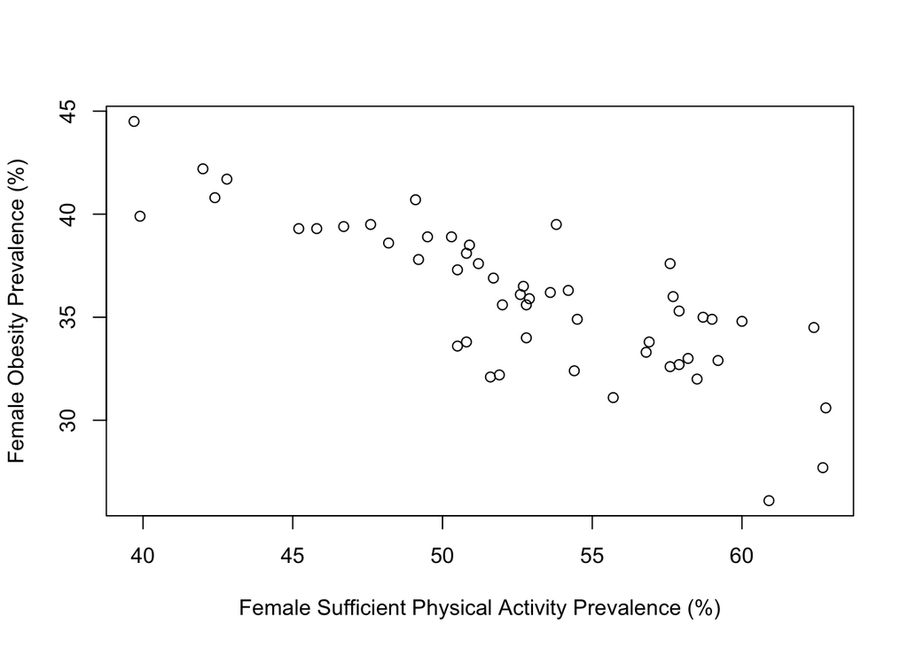

Graph 1: Female Obesity Prevalence (%) vs. Female Sufficient Physical Activity Prevalence (%)

This scatter plot shows the percentage of female obesity prevalence compared to the percentage of female sufficient physical activity prevalence in each state. This graph displays the correlation that with more participation in physical activity, the prevalence of obesity of females decreases. Thus, from this graph as well as the negative slope seen, it demonstrates that the percentage of women that engage in sufficient physical activity are less prone to obesity. It provides insights of the relevant topic of obesity and how promoting physical activity, in an aspect, can help to combat it.

Research Question 2: How does geography affect obesity? Since different regions of the United States have differing cuisines, does diet based on geographical location have a large enough influence on obesity in the US. Are certain diets more susceptible to obesity or other health problems such as Diabetes?

[Dataset 2:](https://www.cdc.gov/obesity/data/prevalence-maps.html)

Plot 2: Prevalence of Obesity (%) by State

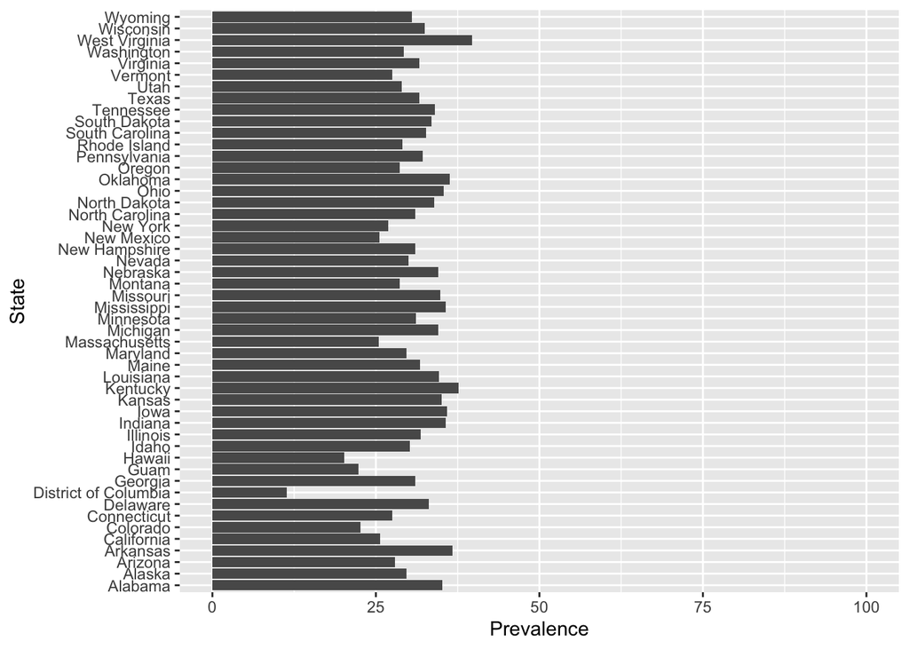

Graph 2: Prevalence of Obesity by State

[Dataset 3:](https://stacks.cdc.gov/view/cdc/106273)

Plot 3: Obesity Across Races Grouped by State

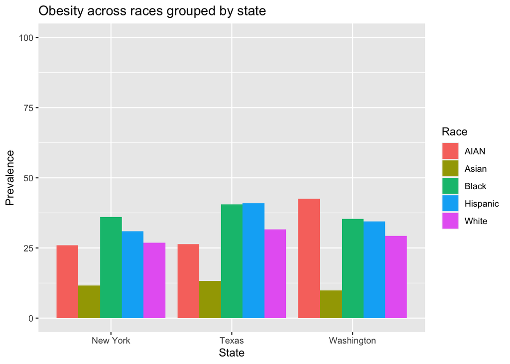

Graph 3: Race/Ethnicity Effect on Obesity

## References:

“Overweight & Obesity Statistics.” National Institute of Diabetes and Digestive and Kidney Diseases, U.S. Department of Health and Human Services, https://www.niddk.nih.gov/health-information/health-statistics/overweight-obesity. Puhl, Rebecca M, and Chelsea A Heuer. “Obesity Stigma: Important Considerations for Public Health.” American Journal of Public Health, American Public Health Association, June 2010, https://www.ncbi.nlm.nih.gov/pmc/articles/PMC2866597/#:~:text=Numerous%20studies%20have%20documented%20harmful,noncompliant%20with%20weight%2Dloss%20treatment. Brody, Jane E. “Half of Us Face Obesity, Dire Projections Show.” The New York Times, The New York Times, 10 Feb. 2020, https://www.nytimes.com/2020/02/10/well/live/half-of-us-face-obesity-dire-projections-show.html. Pearce, Claire, et al. “Obesity Prevention and the Role of Hospital and Community-Based Health Services: A Scoping Review - BMC Health Services Research.” BioMed Central, BioMed Central, 5 July 2019, https://bmchealthservres.biomedcentral.com/articles/10.1186/s12913-019-4262-3#:~:text=Being%20obese%20is%20a%20major,diabetes%20%5B3%2C%204%5D.